# State MSM Profile: **West Virginia**

### Background & Methods

In 2015-2016, researchers at Emory University partnered with colleagues at the Centers for Disease Control and Prevention (CDC) to develop methods to estimate the number of men who have sex with men (MSM) residing in each county in the United States. Using population and housing data from the [American Community Survey](https://www.census.gov/programs-surveys/acs/) and estimates from two peer-reviewed publications ([Oster et al., 2015](http://www.ncbi.nlm.nih.gov/pubmed/26115985) & [Purcell et al., 2012](http://www.ncbi.nlm.nih.gov/pubmed/23049658)), they derived an indirect estimate of MSM population sizes that took into account both the urbanicity of the county as well as its density of households with a male householder and a male same-sex partner.

The full methodology is published in the *Journal of Medical Internet Research - Public Health and Surveillance*:

> [Grey JA, Bernstein KT, Sullivan PS, Purcell DW, Chesson HW, Gift TL, Rosenberg ES. Estimating the population sizes of men who have sex with men in US states and counties using data from the American Community Survey. JMIR Public Health Surveill 2016;2(1):e14. DOI: 10.2196/publichealth.5365](http://publichealth.jmir.org/2016/1/e14/)

### Overview of MSM in West Virginia

An estimated **13,063** men who have sex with men (MSM) resided in West Virginia in 2013, representing 0.3% of the 4,503,084 MSM in the United States. Of the 716,528 adult men of West Virginia, 1.8% had had sex with another man in the past 5 years, which was less than the overall percentage of adult men in the United States who were MSM (3.9%).

Most MSM in West Virginia resided in counties within medium or small metropolitan areas (62.0%). Including both central and fringe counties, 8.1% resided in a large metropolitan area.

##### **Percentage of MSM by urbanicity, United States and West Virginia, 2013**

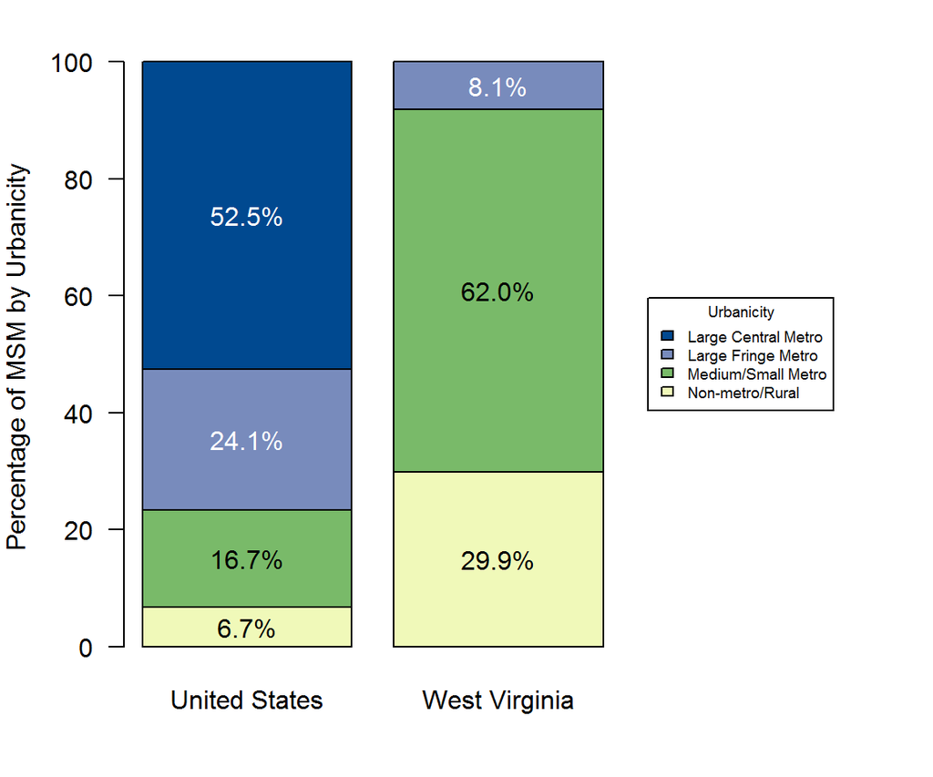

### MSM in West Virginia Counties

Among counties or county-equivalent areas in West Virginia, Kanawha County had the largest population of MSM at 1,577, representing 12.1% of all MSM in the state. Tyler County had the highest percentage of MSM among adult men in West Virginia at 5.5%. This was greater than the percentage for West Virginia as a whole, which was 1.8% of adult men.

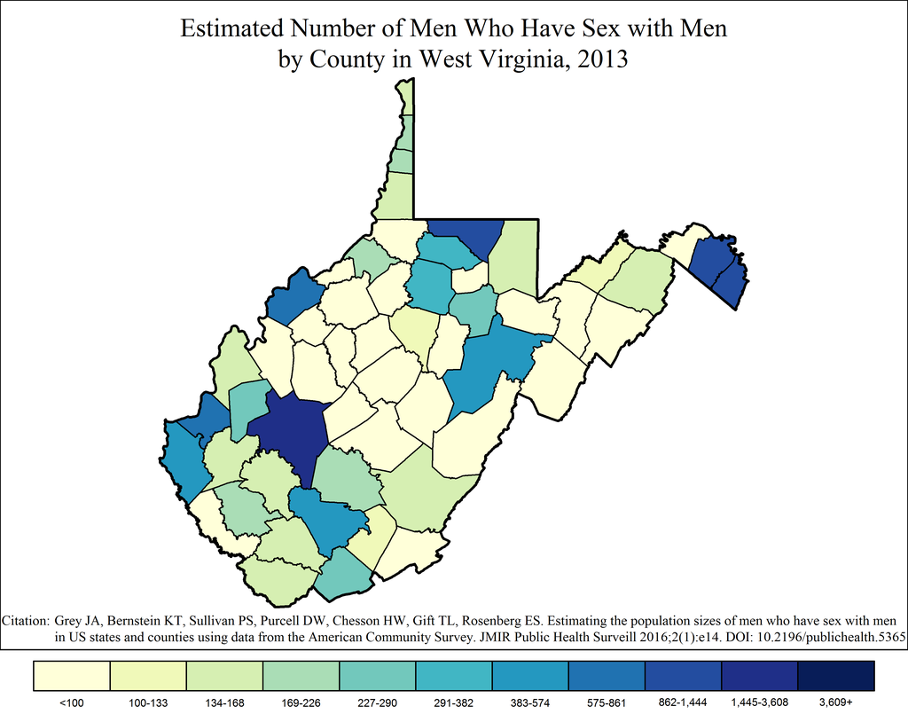

Note: Range cutpoints for the map are based on the distribution of MSM among all counties in the United States.

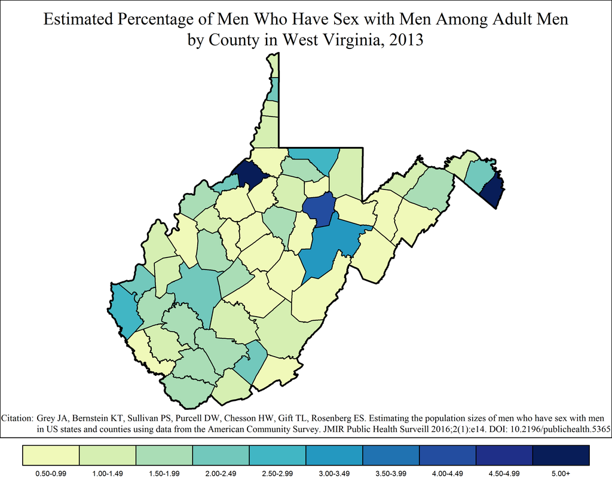

### MSM in West Virginia Metropolitan Statistical Areas

#### Charleston Metropolitan Statistical Area

The Charleston MSA had the largest metropolitan population of MSM in West Virginia at 1,779, or 13.6% of all MSM in the state. Of the 85,179 adult men in Charleston, an estimated 2.1% were MSM.

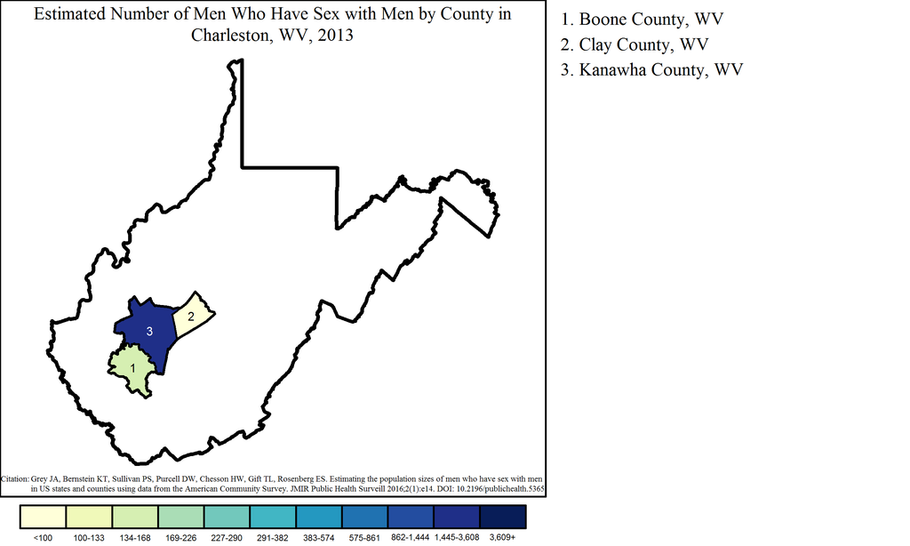

Note: Range cutpoints for the map are based on the distribution of MSM among all counties in the United States.

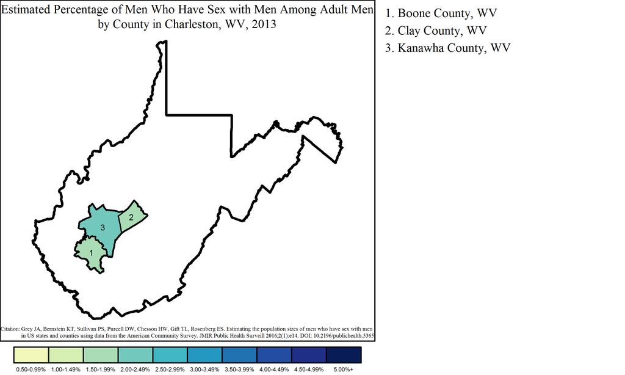

#### Huntington-Ashland Metropolitan Statistical Area

The Huntington-Ashland MSA overlaps three states: Kentucky, Ohio and West Virginia. The West Virginia portion of the MSA had 1,642 MSM, or 12.6% of all MSM in the state and 63.9% of the 2,571 MSM in the MSA. Of 81,949 adult men in the West Virginia part of Huntington-Ashland, 2.0% were MSM. This was greater than the overall percentage of MSM among adult men in the MSA, which was 1.9% of adult men (2,571 out of 137,392).

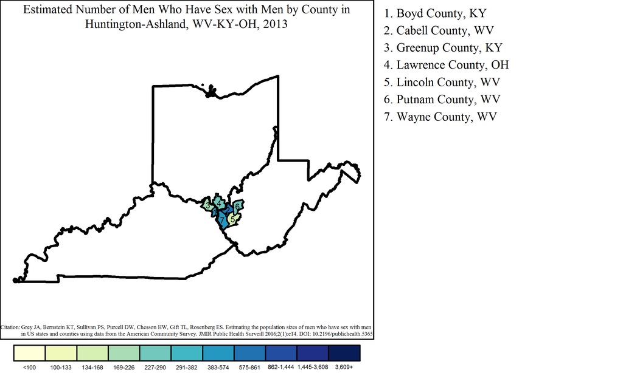

Note: Range cutpoints for the map are based on the distribution of MSM among all counties in the United States.

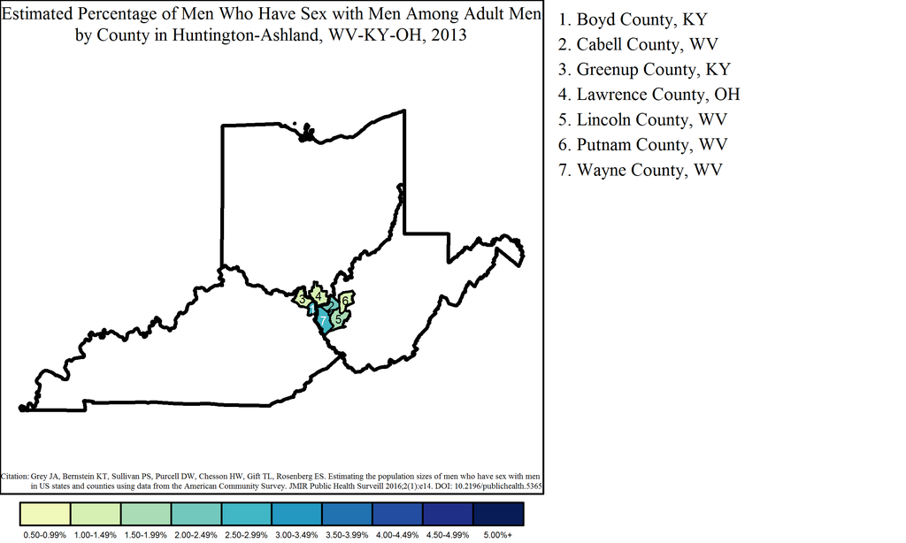

#### Morgantown Metropolitan Statistical Area

The Morgantown MSA had a population of 1,359 MSM, or 10.4% of all MSM in West Virginia. Of the 56,732 adult men in Morgantown, an estimated 2.4% were MSM.

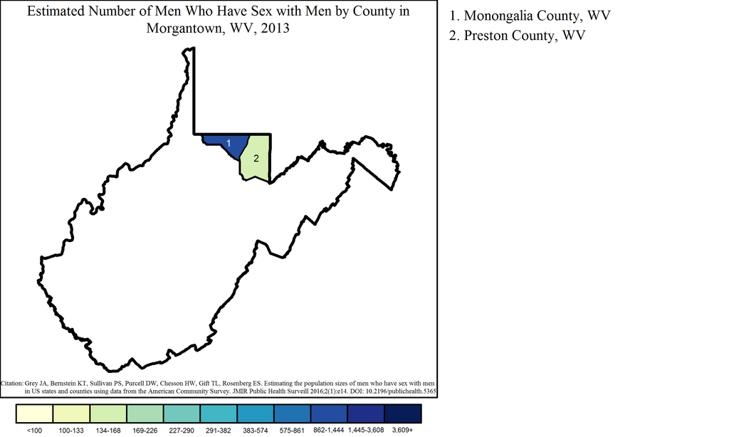

Note: Range cutpoints for the map are based on the distribution of MSM among all counties in the United States.

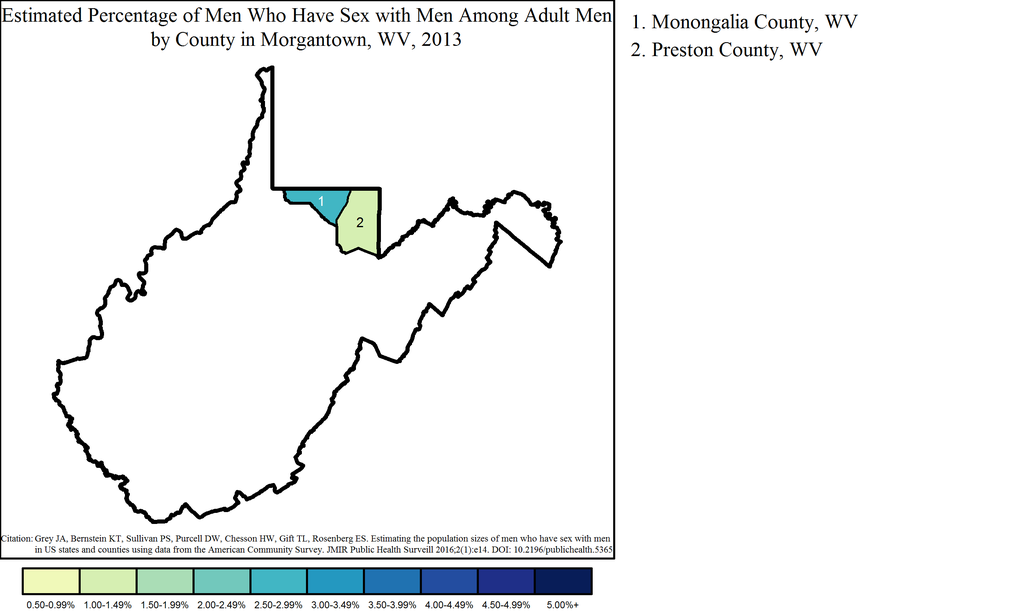

#### Washington-Arlington-Alexandria Metropolitan Statistical Area

The Washington-Arlington-Alexandria MSA overlaps three states – Maryland, Virginia and West Virginia – and the District of Columbia. The West Virginia portion of the MSA had 1,060 MSM, or 8.1% of all MSM in the state and 0.9% of the 122,895 MSM in the MSA. Of 20,271 adult men in the West Virginia part of Washington-Arlington-Alexandria, 5.2% were MSM. This was less than the overall percentage of MSM among adult men in the MSA, which was 5.8% of adult men (122,895 out of 2,113,258).

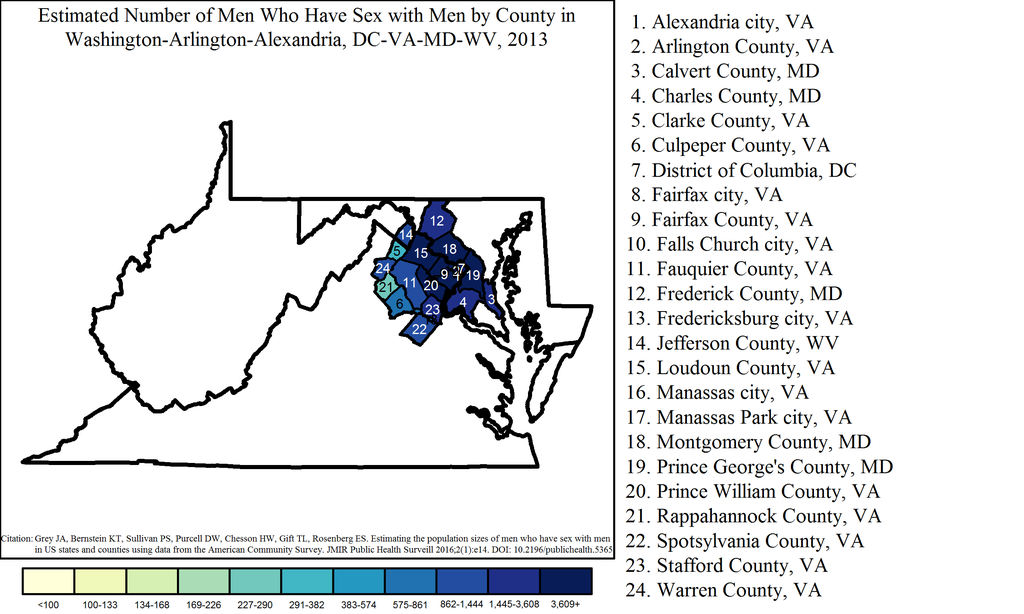

Note: Range cutpoints for the map are based on the distribution of MSM among all counties in the United States.

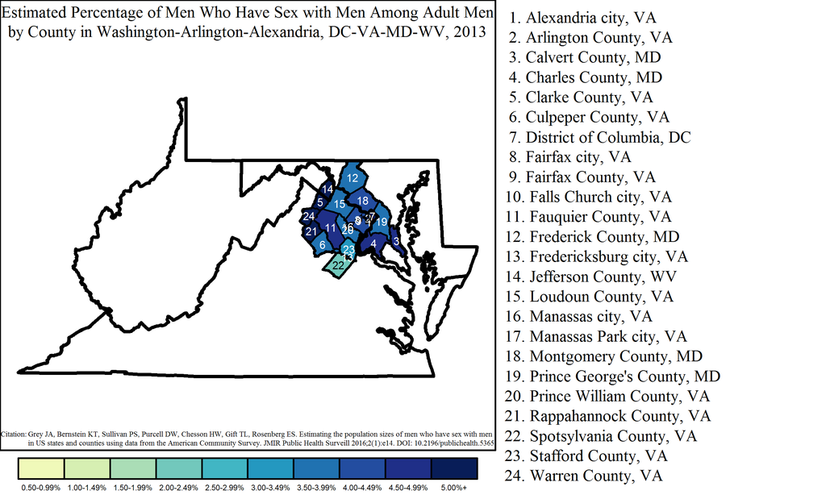

#### Hagerstown-Martinsburg Metropolitan Statistical Area

The Hagerstown-Martinsburg MSA overlaps two states: Maryland and West Virginia. The West Virginia portion of the MSA had 951 MSM, or 7.3% of all MSM in the state and 41.4% of the 2,299 MSM in the MSA. Of 38,966 adult men in the West Virginia part of Hagerstown-Martinsburg, 2.4% were MSM. This was equal to the overall percentage of MSM among adult men in the MSA, which was 2.4% of adult men (2,299 out of 97,379).

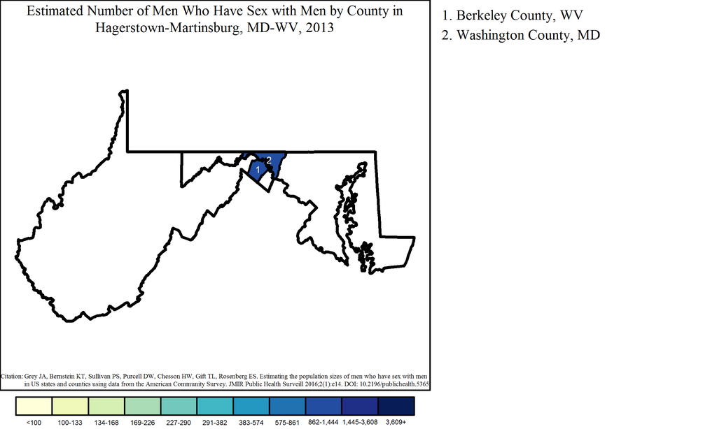

Note: Range cutpoints for the map are based on the distribution of MSM among all counties in the United States.

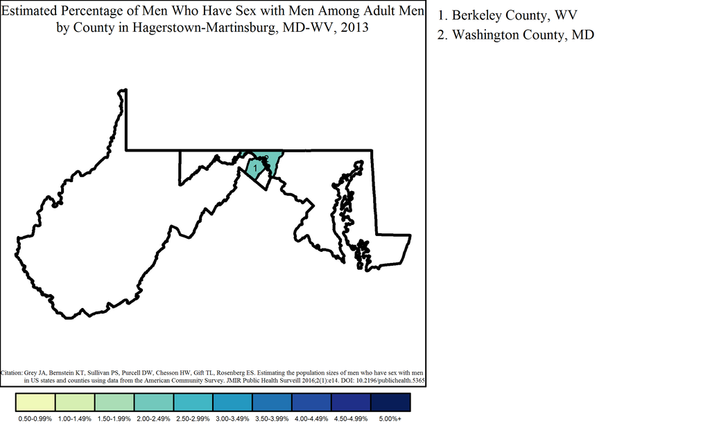

#### Beckley Metropolitan Statistical Area

The Beckley MSA had a population of 686 MSM, or 5.3% of all MSM in West Virginia. Of the 49,162 adult men in Beckley, an estimated 1.4% were MSM.

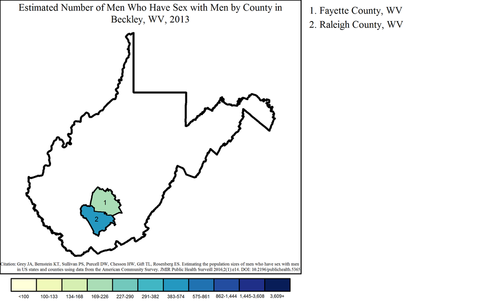

Note: Range cutpoints for the map are based on the distribution of MSM among all counties in the United States.

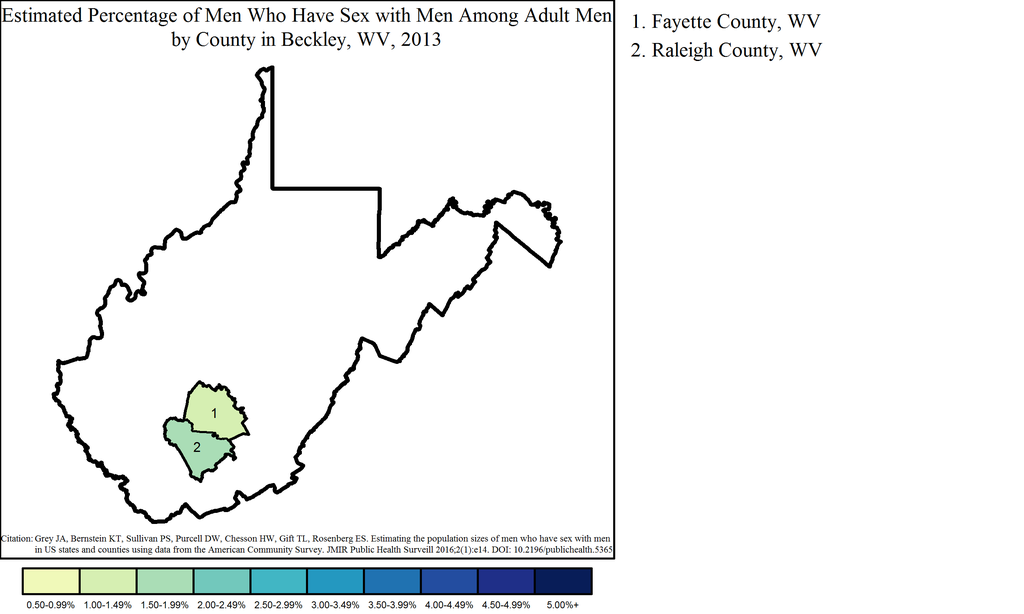

#### Parkersburg-Vienna Metropolitan Statistical Area

The Parkersburg-Vienna MSA had a population of 638 MSM, or 4.9% of all MSM in West Virginia. Of the 34,519 adult men in Parkersburg-Vienna, an estimated 1.8% were MSM.

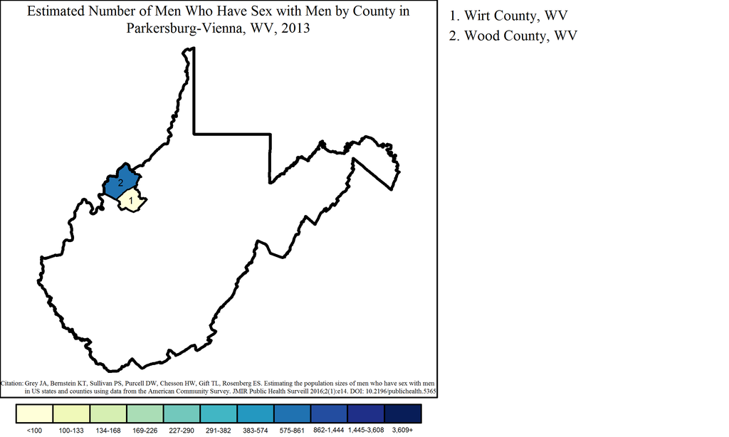

Note: Range cutpoints for the map are based on the distribution of MSM among all counties in the United States.

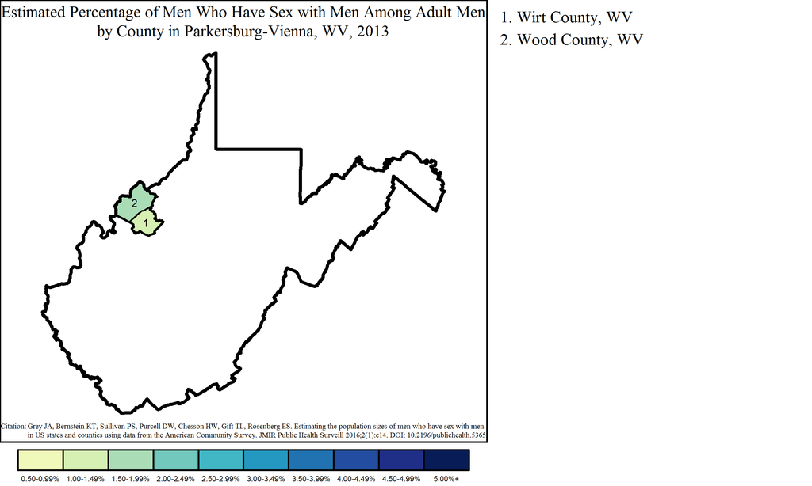

#### Weirton-Steubenville Metropolitan Statistical Area

The Weirton-Steubenville MSA overlaps two states: Ohio and West Virginia. The West Virginia portion of the MSA had 382 MSM, or 2.9% of all MSM in the state and 50.9% of the 750 MSM in the MSA. Of 20,960 adult men in the West Virginia part of Weirton-Steubenville, 1.8% were MSM. This was greater than the overall percentage of MSM among adult men in the MSA, which was 1.6% of adult men (750 out of 47,204).

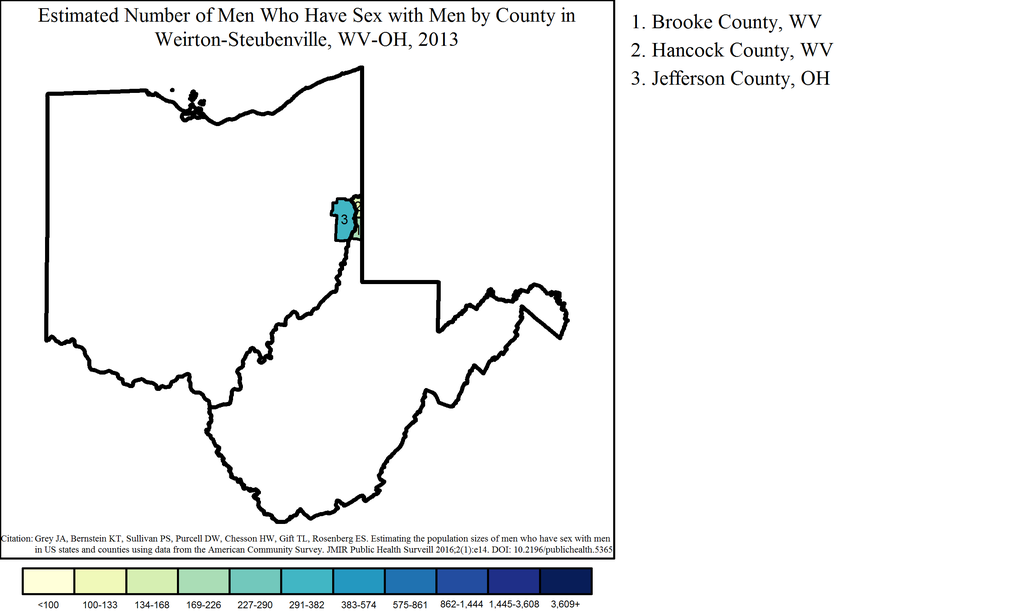

Note: Range cutpoints for the map are based on the distribution of MSM among all counties in the United States.

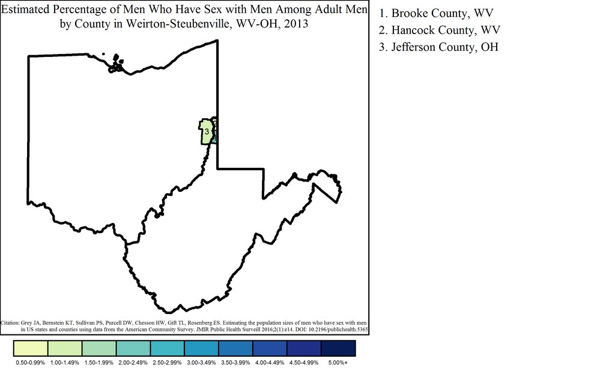

#### Wheeling Metropolitan Statistical Area

The Wheeling MSA overlaps two states: Ohio and West Virginia. The West Virginia portion of the MSA had 379 MSM, or 2.9% of all MSM in the state and 37.7% of the 1,004 MSM in the MSA. Of 29,286 adult men in the West Virginia part of Wheeling, 1.3% were MSM. This was less than the overall percentage of MSM among adult men in the MSA, which was 1.7% of adult men (1,004 out of 57,795).

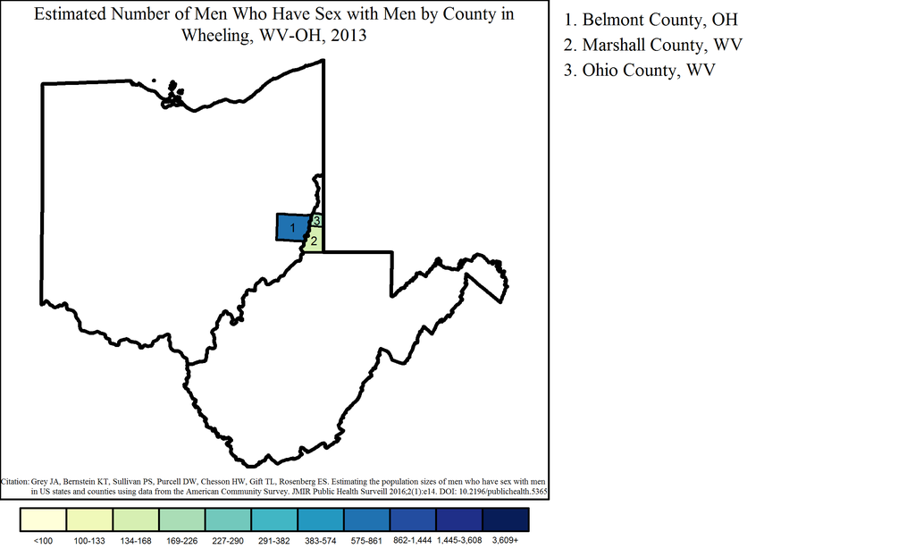

Note: Range cutpoints for the map are based on the distribution of MSM among all counties in the United States.

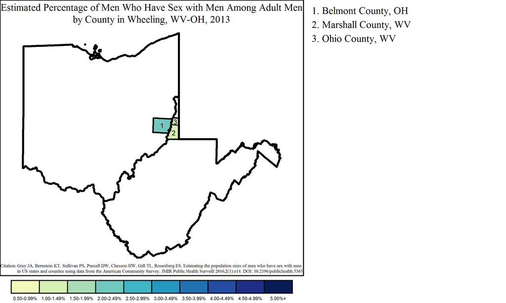

#### Winchester Metropolitan Statistical Area

The Winchester MSA overlaps two states: Virginia and West Virginia. The West Virginia portion of the MSA had 165 MSM, or 1.3% of all MSM in the state and 18.4% of the 896 MSM in the MSA. Of 9,505 adult men in the West Virginia part of Winchester, 1.7% were MSM. This was less than the overall percentage of MSM among adult men in the MSA, which was 1.8% of adult men (896 out of 48,866).

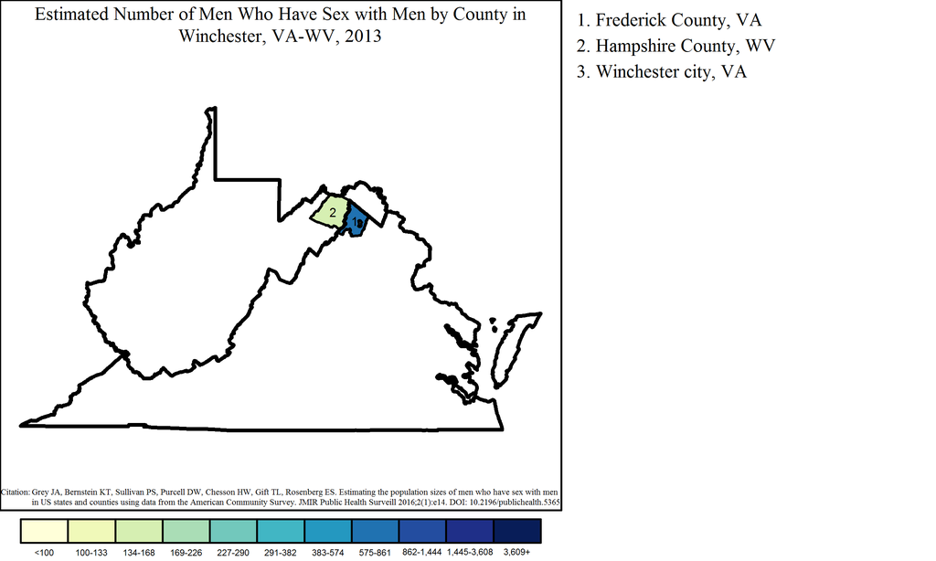

Note: Range cutpoints for the map are based on the distribution of MSM among all counties in the United States.

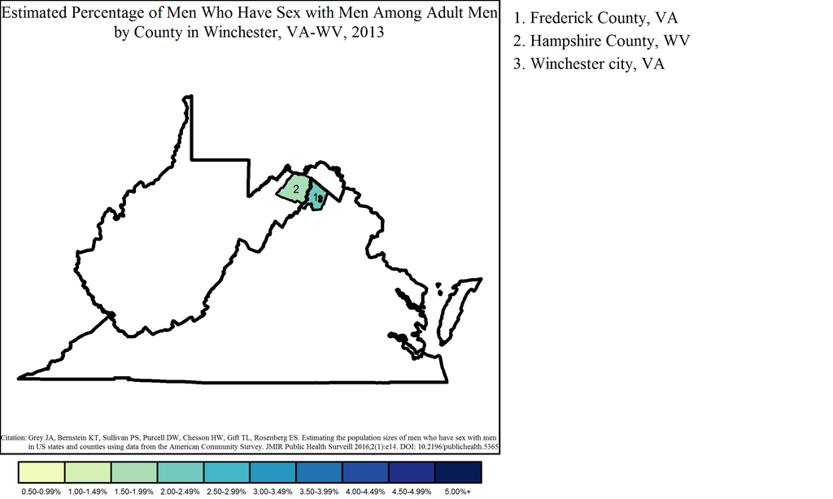

#### Cumberland Metropolitan Statistical Area

The Cumberland MSA overlaps two states: Maryland and West Virginia. The West Virginia portion of the MSA had 117 MSM, or 0.9% of all MSM in the state and 11.5% of the 1,014 MSM in the MSA. Of 10,798 adult men in the West Virginia part of Cumberland, 1.1% were MSM. This was less than the overall percentage of MSM among adult men in the MSA, which was 2.4% of adult men (1,014 out of 42,491).

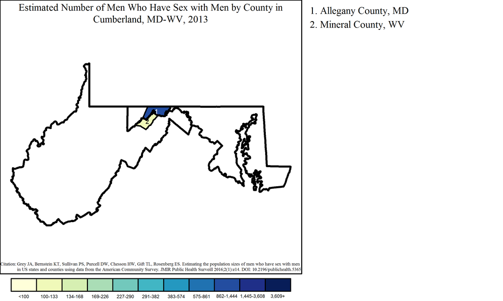

Note: Range cutpoints for the map are based on the distribution of MSM among all counties in the United States.

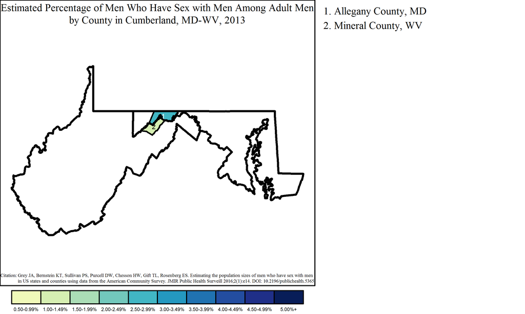